# Curso R

Trabajo Práctico Final

15/11/2019

#### **Consigna**

Elaborar un breve informe en formato html utilizando R Markdown. Para ello deberán seleccionar una base de datos que sea de su conocimiento y que utilicen habitualmente en su trabajo. Con la misma deberán preparar como mínimo 4 tabulados distintos. Las tablas deberán aparecer en el informe con una breve explicación/descripción de su contenido.

Luego, deberán presentar de forma gráfica al menos 2 de los tabulados realizados, utilizando gráficos que sean de distinto tipo. Tendrán que especificar el título, la fuente y los nombres de los ejes.

Deberán entregar el informe en formato .html y en .rmd.

A continuación se recuerdan algunas de las funciones vistas durante el desarrollo del curso que servirán para la elaboración del TP:

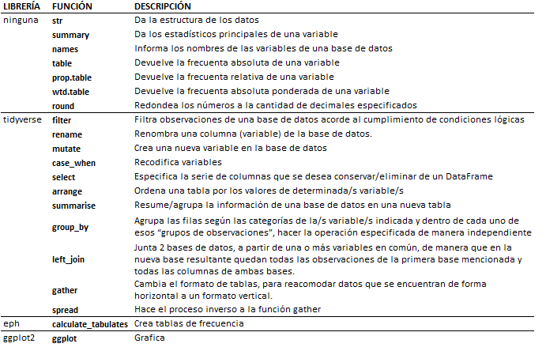

*Este trabajo práctico es requisito para la aprobación del curso. El mismo podrá ser desarrollado durante la última clase (15/11/19), de manera que puedan consultar todas sus dudas. En caso que el tiempo no les resulte suficiente, tendrán la posibilidad de finalizarlo en sus casas.*